# summary

## Summary of Model Performance:

Score: 0.87

- SVC achieved the highest accuracy among the models, indicating it performs well with this dataset, likely due to its ability to find optimal hyperplanes for classification. Naive Bayes Classifier:

Score: 0.77

- Naive Bayes performed decently but is more simplistic and may struggle with feature dependencies that violate its independence assumption. AdaBoost Classifier:

Score: 0.73

- AdaBoost gave a reasonable result, but its performance may depend on the quality of the weak learners, which may not have captured the complexities of the data as well as other models. Decision Tree Classifier:

Score: 0.57

- Decision Trees tend to overfit when they grow deep, and the relatively lower score suggests overfitting could have been an issue here. Random Forest Classifier:

Score: 0.80

- Random Forest performs well due to the ensemble nature of combining many decision trees, making it more robust than a single decision tree and less prone to overfitting. K-Nearest Neighbors Classifier (KNN):

Score: 0.80

- KNN also performed well but may be sensitive to noisy data and is computationally expensive as the number of data points grows.

[figure not shown]

```python
# data preparaion
dataset = load_iris()
data = dataset.data
target = dataset.target

cols = dataset.feature_names
cols = [x[:-5].replace(' ','_') for x in cols]
df = pd.DataFrame(data=np.c_[data,target], columns=cols+['target'])
df.drop_duplicates(inplace=True)

X = df.copy()
y = X.pop('target')

scaler = StandardScaler()
scaler.fit(X)
X = scaler.transform(X)
X_train, X_test, y_train, y_test = train_test_split(X,y,test_size=0.2)

# Only the first two features (sepal length and sepal width) are used for simplicity in visualizing decision boundaries.
X_train = X_train[:, :2]
X_test = X_test[:, :2]
```

```python
#-----------------------------------------------------------------------------
scores = []
models = ['Support Vector Classifier', 'Naive Bayess classifier', 'AdaBoost Classifier', 'Decision Tree Classifier', 'RandomForest Classifier',
          'KNeighbours Classifier']

#-----------------------------------------------------------------------------
```

```python
# Support Vector Classifier
svc = SVC()

params = {
    'C': [0.1, 1, 10, 100],
    'gamma': ['scale', 'auto', 0.001, 0.01, 0.1, 1],
    'kernel': ['linear', 'rbf', 'sigmoid'],
    'degree': [2, 3, 4],
    'coef0': [0, 0.1, 0.5, 1]
}

grid_search = GridSearchCV(svc, params, cv=5, scoring='accuracy', n_jobs=-1, verbose=2)
grid_search.fit(X_train, y_train)

best_params = grid_search.best_params_
best_model = grid_search.best_estimator_

print("Best Parameters:", best_params)
print("Best Cross-Validation Accuracy:", grid_search.best_score_)

r2 = best_model.score(X_test, y_test)
print("SVC R2:", r2)

scores.append(r2)



# Naive Bayess classifier
model = GaussianNB()

model.fit(X_train,y_train)

r2 = model.score(X_test, y_test)

print("Bayess R2:", r2)

scores.append(r2)




# Adaboost classifier
adaboost = AdaBoostClassifier(n_estimators=1000)

params = {
    'n_estimators': [50, 100, 200],  # Number of boosting stages
    'learning_rate': [0.01, 0.1, 1.0],
    'algorithm': ['SAMME']
}

grid_search = GridSearchCV(adaboost, params, cv=5, scoring='r2')

grid_search.fit(X_train, y_train)

best_params = grid_search.best_params_
best_model = grid_search.best_estimator_

print("Best Parameters:", best_params)
print("Best Model:", best_model)

r2 = best_model.score(X_test, y_test)
print("Adaboost R2:", r2)

scores.append(r2)




# Tree classifier
tree = DecisionTreeClassifier()

params = {
    'criterion': ['entropy', 'gini'],
    'max_depth': [10, 20, 30],
    'min_samples_split': [2, 10, 20],
    'min_samples_leaf': [3, 5, 10],
    'max_features': ['sqrt', 'log2']
}

grid_search = GridSearchCV(tree, params, cv=5, scoring='r2')

grid_search.fit(X_train, y_train)

best_params = grid_search.best_params_
best_model = grid_search.best_estimator_

r2 = best_model.score(X_test, y_test)
print("Tree regressor R2:", r2)

scores.append(r2)




# Random forest classifier
randomforest = RandomForestClassifier()

params = {
    'n_estimators': [50, 100, 200],
    'max_depth': [5, 10, 15],
    'min_samples_split': [2, 5],
    'min_samples_leaf': [1, 4],
    'max_features': ['sqrt', 'log2'],
    'bootstrap': [True]
}

grid_search = GridSearchCV(randomforest, params, cv=5, scoring='r2', n_jobs=-1, verbose=0)

grid_search.fit(X_train, y_train)

best_params = grid_search.best_params_
best_model = grid_search.best_estimator_

r2 = best_model.score(X_test, y_test)
print("Random Forest R2:", r2)

scores.append(r2)




# K-Neighbours classifier
kneighbours = KNeighborsClassifier()
params = {
    'n_neighbors': [5, 7, 10],
    'weights': ['uniform', 'distance'],
    'algorithm': ['auto', 'ball_tree', 'kd_tree', 'brute'],
    'leaf_size': [20, 30, 40],
    'p': [1, 2]
}

grid_search = GridSearchCV(kneighbours, params, cv=5, scoring='r2', n_jobs=-1, verbose=2)

grid_search.fit(X_train, y_train)

best_params = grid_search.best_params_
best_model = grid_search.best_estimator_

r2 = best_model.score(X_test, y_test)
print('K-Neighbours R2: {0:.2f}'.format(r2))

scores.append(r2)
```

```
Fitting 5 folds for each of 864 candidates, totalling 4320 fits
Best Parameters: {'C': 1, 'coef0': 0, 'degree': 2, 'gamma': 0.1, 'kernel': 'sigmoid'}
Best Cross-Validation Accuracy: 0.8072463768115942
SVC R2: 0.8666666666666667
Bayess R2: 0.7666666666666667
Best Parameters: {'algorithm': 'SAMME', 'learning_rate': 0.1, 'n_estimators': 100}
Best Model: AdaBoostClassifier(algorithm='SAMME', learning_rate=0.1, n_estimators=100)
Adaboost R2: 0.7333333333333333
Tree regressor R2: 0.5666666666666667
Random Forest R2: 0.8
Fitting 5 folds for each of 144 candidates, totalling 720 fits
K-Neighbours R2: 0.80
```

```python
print(scores)
models = ['Support Vector Classifier', 'Naive Bayess classifier', 'AdaBoost Classifier', 'Decision Tree Classifier', 'RandomForest Classifier',
          'KNeighbours Classifier']
```

```
[0.8666666666666667, 0.7666666666666667, 0.7333333333333333, 0.5666666666666667, 0.8, 0.8]
```

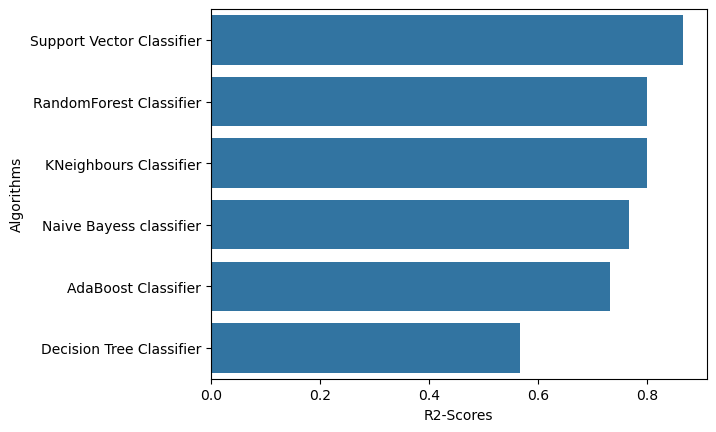

```python
#-----------------------------------------------------------------------------
ranking = pd.DataFrame({'Algorithms' : models , 'R2-Scores' : scores})
ranking = ranking.sort_values(by='R2-Scores' ,ascending=False)
ranking

sns.barplot(x='R2-Scores' , y='Algorithms' , data=ranking)
```